# Vignette Preprocessing HT12-v4 Gene Expression Data

Holger Kirsten & Carl Beuchel

2018-07-05

# Gx Pre-Processing with HT12ProcessoR

```r
# start time measurement
time.start <- Sys.time()

# load required packages
for (i in c(
  "HT12ProcessoR",
  "toolboxH",
  "lumi",
  "knitr",
  "here",
  "data.table",
  "evaluate",
  "plotly",
  "ggplot2",
  "pander"
)) {
  suppressPackageStartupMessages(library(i, character.only = TRUE))
}

# set some basic options
panderOptions('table.split.table', Inf)
options(stringsAsFactors=FALSE)
```

# Preparations

This example shows a typical preprocessing of ILLUMINA HT12v4 data using the package HT12ProcessoR. This can be applied for a few samples up to thousands of samples. Details on the Illumina technology can be found here: http://support.illumina.com/content/dam/illumina-marketing/documents/products/datasheets/datasheet_gene_exp_analysis.pdf

This packages comes with an included example (a subset with 96 Chips from GEO accession: GSE65907). This data can be found in /net/ifs1/san_projekte/projekte/genstat/07_programme/rpackages/amanMRO/HT12ProcessoR/extdata. All annotation files needed for the preprocessing are stored as an .RData object in the data/ folder of this package. For this vignette, please set a working directory (`setwd(path/to/project)`), where all files created by this package will be stored.

## Check dependencies

Firstly, package dependencies must be met. When installation of the package fails due to missing dependencies, please check whether you can get those dependencies via CRAN, e.g. `install.packages()` or [Bioconductor](https://www.bioconductor.org/install/). The package `toolboxH` contains convenience-functions by the package creator and can be downloaded [here](https://github.com/holgerman/toolboxH).

## Prepare example files

- Start with Data from Illuminas GenomeStudio. Data should be non-normalized, non-background-substracted. Illumina organises expression data in filesets consisting of three files, a sample file with gene probe data, a control files with control probe data and a sample file with individidual-related information
- A tab-delimeted file should be created specifying location of these three files. Following columns are required:
  - `fileset_id`: a short ID for a fileset
  - `con_f`: full path and filename of the control probe centric data file
  - `nobkgd_f`: full path and filename of the gene probe centric data file
  - `sample_f`: full path and filename of the sample centric data file
- The file should be saved in the folder intended for preprocessing the data

```r
# check the root of your project
# here::dr_here(show_reason = T) #  the here package makes the navigation in directories easier but works best from within R-Projects

# get the project root directory
# prepro.folder <- here()
# setwd(/path/to/project)
prepro.folder <- getwd() # please choose a working directory

# create the object with the names of the input files ##
# IDs can be chosen freely, but using terms identifying the data files might be advisable
my.fileset_id <- c('590-651', 'HSS106-HSS155')

# create the results-folder if necessary
dir.create(paste0(prepro.folder, "/tosend/"))

# also create an obj/ folder for intermediary results
dir.create(paste0(prepro.folder, "/obj/"))

# control probe data file
my.con_f <- c(system.file("extdata", "Run12_ControlProbeProfile_590-651.txt", package = "HT12ProcessoR"), # control probe measurements + ercc (spike-in -- class of control probes)
              system.file("extdata", "ControlProbeProfile_HSS106-HSS155.txt", package = "HT12ProcessoR")) #  second example (processing batch 1 & 2)

# gene probe file
my.nobkgd_f <- c(system.file("extdata", "Run12_nonorm_nobkgd_590-651.txt", package = "HT12ProcessoR"), # raw probe data of human gene expression
                 system.file("extdata", "Einzelanalyse_nonorm_nobkgd_HSS106-HSS155.txt", package = "HT12ProcessoR"))

# sample file
my.sample_f <- c(system.file("extdata", "Run12_SamplesTable_590-651.txt", package = "HT12ProcessoR"), # sample annotation (each measured indiviuum)
                 system.file("extdata", "SamplesTable_HSS106-HSS155.txt", package = "HT12ProcessoR"))

# consolidate in input-file
input <- data.table(fileset_id = my.fileset_id,
                    con_f = my.con_f,
                    nobkgd_f = my.nobkgd_f,
                    sample_f = my.sample_f)

# how should the input file be called?
input_filename <- paste0(prepro.folder, "/obj/01_file_overview.txt")

# save the input file for later use
write.table(x = input,
            file = input_filename,
            quote = F,
            col.names = T,
            row.names = F,
            sep = "\t")
```

## Prepare parameter file

Next, customize project-specific variables in a parameter file. This file is used to provide most relevant parameters in a single place for the individual preprocessing functions. Parameters will also be explained later. An example is provided with this package

```r
myparams <- read.delim(system.file("extdata", "input_parameter_010.txt", package = "HT12ProcessoR"),
                       as.is = T)
```

Project-specific parameters that should be customized initially are:

- `file_names_of_files_and_folders`: Location of the files to preprocess; this is the `input_filename` created in the previous step
- `datafolder_results`: Directory, where the results of preprocessing can be stored

```r
# where is the input file we created located?
myparams[myparams$variable == "file_names_of_files_and_folders", "value"] <- input_filename

# where should the results be saved?
myparams[myparams$variable == "datafolder_results", "value"] <- paste0(prepro.folder, "/tosend/")

# where should the file be saved (overwrite the previously read-in file)
myparamfile <- paste0(prepro.folder, "/obj/input_parameter_010.txt")

# save the file again with the above changes
write.table(myparams,
            myparamfile,
            quote = F,
            col.names = T,
            row.names = F,
            sep="\t")
```

# Step 1 - Function `checkExtractChipsamples`: Check given expression files and extract individuals

This step does the following:

- checks files specified in myparamfile for:
  - are expected files present
  - does each file have information for each sample
  - are multiple identical IDs in different expression files present, if yes, this will be resolved according to parameter `renameDublettes`
  - properly formated sentrix IDs for all samples present
  - sentrix IDs for all samples present
  - 47323 ILMN gene expression probes present in all files
  - 883 ILMN control probes present in all files
- create list-object of class **HT12prepro** including a slot with sample-related attributes of the current processing-stage named `$chipsamples`

```r
# execute function for the checks described above
prepro_ht12 <- checkExtractChipsamples(paramfile = myparamfile) # check the output of the function for details
```

```
## Using files as input found in /net/ifs1/san_projekte/projekte/Doktoranden/CarlBeuchel/6_RPackages/HT12ProcessoR/vignettes/obj/01_file_overview.txt
```

```
## Allways complete filesets identified, i.e. three files of type 'nobkgd', 'con' and 'sample', no problem identified.
```

```
## reading /net/ifs1/san_projekte/projekte/genstat/07_programme/rpackages/amanMRO/HT12ProcessoR/extdata/Run12_nonorm_nobkgd_590-651.txt
```

```
## reading /net/ifs1/san_projekte/projekte/genstat/07_programme/rpackages/amanMRO/HT12ProcessoR/extdata/Einzelanalyse_nonorm_nobkgd_HSS106-HSS155.txt
```

```
## reading /net/ifs1/san_projekte/projekte/genstat/07_programme/rpackages/amanMRO/HT12ProcessoR/extdata/Run12_ControlProbeProfile_590-651.txt
```

```
## reading /net/ifs1/san_projekte/projekte/genstat/07_programme/rpackages/amanMRO/HT12ProcessoR/extdata/ControlProbeProfile_HSS106-HSS155.txt
```

```
## reading /net/ifs1/san_projekte/projekte/genstat/07_programme/rpackages/amanMRO/HT12ProcessoR/extdata/Run12_SamplesTable_590-651.txt
```

```
## reading /net/ifs1/san_projekte/projekte/genstat/07_programme/rpackages/amanMRO/HT12ProcessoR/extdata/SamplesTable_HSS106-HSS155.txt
```

```
##
## All sample IDs present in all three files of type 'nobkgd', 'con' and 'sample', no problem found.
```

```
## Sentrix ID allways found with 10 or 11 digits, no problem identified.
```

```
##
## check following file for presence of 47,323 ilmn-probes:      /net/ifs1/san_projekte/projekte/genstat/07_programme/rpackages/amanMRO/HT12ProcessoR/extdata/Run12_nonorm_nobkgd_590-651.txt
```

```
##
## check following file for presence of 47,323 ilmn-probes:      /net/ifs1/san_projekte/projekte/genstat/07_programme/rpackages/amanMRO/HT12ProcessoR/extdata/Einzelanalyse_nonorm_nobkgd_HSS106-HSS155.txt
```

```
## All expression files included  47323 Illumina probes, no problem identified.
```

```
## Check following file for presence of 883 Illumina-control probes:      /net/ifs1/san_projekte/projekte/genstat/07_programme/rpackages/amanMRO/HT12ProcessoR/extdata/Run12_ControlProbeProfile_590-651.txt
```

```
## Check following file for presence of 883 Illumina-control probes:      /net/ifs1/san_projekte/projekte/genstat/07_programme/rpackages/amanMRO/HT12ProcessoR/extdata/ControlProbeProfile_HSS106-HSS155.txt
```

```
## No different IDs for identical samples used within columns "Sample.ID", "Sample_ID", and rownames of Expressionfiles, no problem identified.
```

```r
# print object in HTML-report
pander(prepro_ht12$history)

# check the class of the object
class(prepro_ht12)

# another file preview
pander(ht(prepro_ht12$chipsamples, 1))
```

# Step 2 - Designate individuals and subgroups for preprocessing and redefine batches

**Exclude samples:**

- Samples can be excluded if they should not be included in preprocessing, e.g. if they are genotyped on the same chip but are from a totally different project
- For this, column `old_ID` in `prepro_ht12$chipsamples` can be used, which reports the original ID used in the raw data from column `Sample ID` of the sample-file from ILLUMINA

**Designate subgroups:**

- Major subgroups that, should treated independet, of the data should be specified
- A typical example is if data from different tissue is preprocessed together
- This will force the functions that the number of detected and expressed probes as well as the Euclidian distance of all expressed probes (used to define atypical samples) are calculated subgroup-specific

**Alternative treatment of subgoups:**

- Optionally, batch effect correction by function `removeBatchEffects()` can be done by preserving the subgroup contrast
- Additionally, up to three (nested) batches can be specified, that should reflect processing
  - Default First-level batch is `Sentrix.Barcode`, the Chip-ID.
  - Typically, several chips are processed together, this variable is defined as `processingbatch` - The default is the column `fileset_id` from the above file `input_filename`
  - Finally, sometimes several runs behave differently, these might be specified in the variable `strangebatch` - default here is `0`

```r
# preview first and last lines
pander(ht(prepro_ht12$chipsamples, 2))

# define samples to be excluded, e.g. when different projects are processed on the same chip
exclude.this <- c("614", "638", "HSS 108", "HSS 112", "HSS 115", "HSS 125", "HSS 127", "HSS 133", "HSS 137", "HSS 138", "HSS 146", "HSS 151","HSS 155")

# Exclude Samples by modifying the $chipsamples element
prepro_ht12$chipsamples <- prepro_ht12$chipsamples[!prepro_ht12$chipsamples$old_ID  %in% exclude.this, ]

# Define Subgroups -  in this example, sampels are from Peripheral Blood Mononuclear Cells (PBMC)
prepro_ht12$chipsamples$subgroup <- "PBMC"
table(prepro_ht12$chipsamples$subgroup)

# show which IDs were processed in which batch
xtabs(~prepro_ht12$chipsamples$Sentrix.Barcode + prepro_ht12$chipsamples$processingbatch)

# do we have strange batches on top of regular batch structure
xtabs(~prepro_ht12$chipsamples$strangebatch + prepro_ht12$chipsamples$processingbatch)

## Quick Check for major differences based on Attributes from the provided ILLUMINA-sample-files
initial_pca <- calcInitialPCA(prepro_ht12)
```

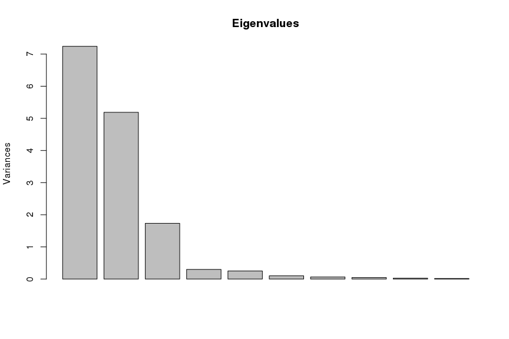

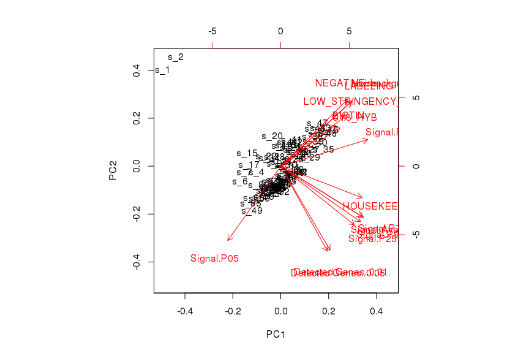

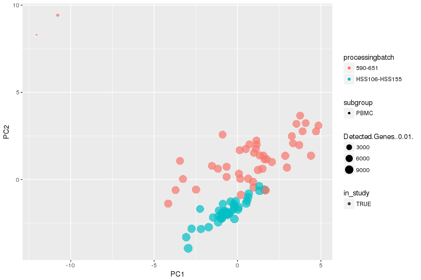

```r
# plot the results
pca.plot <- ggplot(initial_pca$scores, aes(PC1,
                                           PC2,
                                           pch = subgroup,
                                           col = processingbatch,
                                           size = Detected.Genes..0.01.,
                                           alpha = in_study,
                                           label = paste(old_ID, new_ID, sep = "\n"))) +
  geom_point() +
  scale_alpha_manual(values = c(0.7, 0.3))

# plot a static version
pca.plot
```

```r
# interactive visualisation - check homogeinity etc.
pca.plot %>% ggplotly()
```

```
## We recommend that you use the dev version of ggplot2 with `ggplotly()`
## Install it with: `devtools::install_github('hadley/ggplot2')`
```

# Step 3 - Function `createExpressionSet()`: Create an expression set and related information from data

In this step, the expression information that is scattered across many files is united in a single expression set object. This includes control probe information.

Among others, following slots will be created within the updated HT12prepro-object among others:

- a slot with sample-related attributes of the current processing-stage named `$chipsamples`
- a slot with the R-object holding expression data used to create the expression set named `$rawdataWOcons_joined`
- a slot with the R-object holding control data used to create the expression set named `$rawdataOnlycons_joined`
- a slot with the R-object holding control data used to create the expression set named `$rawdataOnlycons_joined`
- a slot with expression-set expression data excluding control data named `$all_nobkgd_eset`
- a slot with expression-set expression data including control data named `$total_nobkgd_eset`
- a slot with the history of the commands named `$history`

Additionally, integrity checks are carried out:

- check whether gene expression data and control expression data for all samples have been imported
- check for NAs present in gene expression and control expression data
- check for negative gene expression values in gene expression and control expression data and, if found, replaced with the lowest expression value found
- check for similar values of [ERCC](http://www.thermofisher.com/order/catalog/product/4456740) probes and housekeeping probes in gene-expression and control-expression data as Illumina reports them in both of the corresponding files

```r
# create the ExpressionSet
prepro_ht12 <- createExpressionSet(prepro_ht12, paramfile = myparamfile) # watch the function output
```

```
## Import file 1: /net/ifs1/san_projekte/projekte/genstat/07_programme/rpackages/amanMRO/HT12ProcessoR/extdata/Run12_nonorm_nobkgd_590-651.txt...
```

```
## Import file 2: /net/ifs1/san_projekte/projekte/genstat/07_programme/rpackages/amanMRO/HT12ProcessoR/extdata/Einzelanalyse_nonorm_nobkgd_HSS106-HSS155.txt...
```

```
## Succesfully imported expression information (Detection.Pval) from all samples, no problem found.
```

```
## Succesfully imported expression information (AVG_Signal) from all samples, no problem found.
```

```
## Did not find any 'NA' value within expression values, no problem identified.
```

```
## Did not find any negative expression value, no problem identified.
```

```
##
## Importing control expression data....
```

```
## Import control file 1: /net/ifs1/san_projekte/projekte/genstat/07_programme/rpackages/amanMRO/HT12ProcessoR/extdata/Run12_ControlProbeProfile_590-651.txt...
```

```
## Import control file 2: /net/ifs1/san_projekte/projekte/genstat/07_programme/rpackages/amanMRO/HT12ProcessoR/extdata/ControlProbeProfile_HSS106-HSS155.txt...
```

```
## Did not find all 883 controls in file /net/ifs1/san_projekte/projekte/genstat/07_programme/rpackages/amanMRO/HT12ProcessoR/extdata/ControlProbeProfile_HSS106-HSS155.txt
```

```
## Succesfully imported control-expression information from  (Detection.Pval) all samples, no problem found.
```

```
## Succesfully imported expression information (AVG_Signal) from all samples for control probes, no problem found.
```

```
## Did not find any negative control-expression values, no problem identified.
```

```
## check whether similar fields in input data have indeed the same data (if '1', than test is ok, i.e. the same information was found accross those fields):
```

```
## 1
```

```
## ERCC expression levels are the same for identical probes in expression files and control files, no problem identified
```

```
## Writing temporary file named/tmp/RtmpHzuRmS/file1993144b2181c in order to create expressionset of gene probes as well as control probes via R-package lumi...
```

```
## Creating  expressionset of gene probes as well as control probes via lumi...
```

```r
# explore file output
# show the command history
kable(prepro_ht12$history)

# preview expressionset including samples and controls
prepro_ht12$total_nobkgd_eset

# detection levels per probe
hh(lumi::detection(prepro_ht12$total_nobkgd_eset))

# expression lvl per probe
hh(lumi::exprs(prepro_ht12$total_nobkgd_eset))
```

# Step 4 - Function `filterLowExpressed`: Filter badly expressed individuals & mark badly expressed genes

This step includes:

- Filter samples for extreme number of expressed transcripts and annotate transcripts for extreme numbers of samples not found to have the transcript expressed
- Filtering samples for extreme numbers of expressed transcripts uses parameter `filter1ind_expressedGenes`as threshold for the number of interquantile ranges of the number of detected probes to be tolerated. The definition of detection is related to a ILLUMIN-defined detection p-value of 0.01
- Annotating transcripts for having extreme numbers of samples where ´expressed´ uses parameter `filter1probes_expressedProbes`as threshold, default is 0.05

Changes to the HT12prepro-object, among others, are:

- The slot with sample-related attributes of the current processing-stage named `$chipsamples` is updated
- A slot with the detailed probe-related expression level informationis created named `$genesdetail`
- The slot with the history of the commands named `$history` is updated

```r
# execute step 4 by running this function
prepro_ht12 <- filterLowExpressed(prepro_ht12, paramfile = myparamfile)
```

```
## processing subgroup 'PBMC' ...
```

```
## Remaining samples acrosss all subgroups:
## 81, i.e. 2 were filtered due to atypical number of expressed genes...
```

```
## Across remaining 81 samples from subgroup PBMC, 36.7% probes are classified as expressed...
```

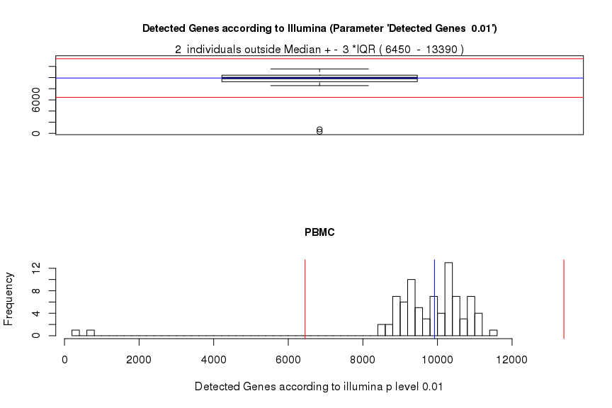

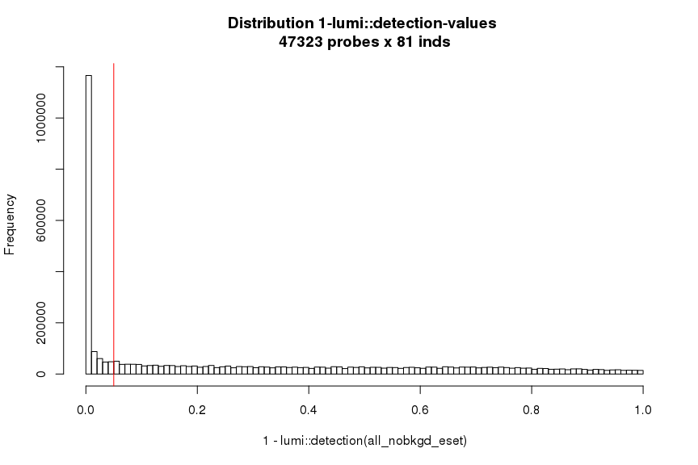

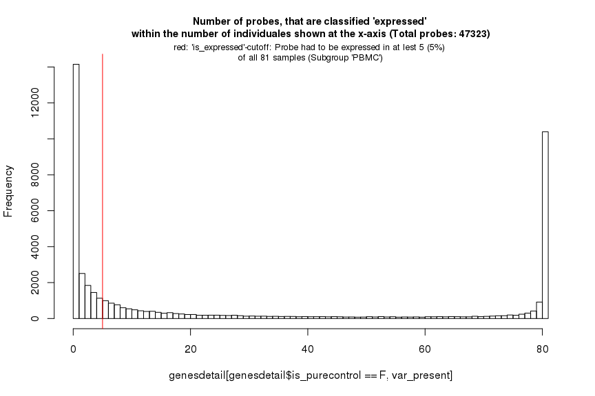

```r
# show command history
kable(prepro_ht12$history)

# preview function output
head(prepro_ht12$genesdetail)

# show excluded samples
setDT(prepro_ht12$chipsamples)
prepro_ht12$chipsamples[,.N,.(in_study, reason4exclusion)]

# and reset class of this object
setDF(prepro_ht12$chipsamples)
```

# Step 5 - Functions `transformNormalizeHT12object()` and `filterTechnicallyFailed()` Transform & normalize data & filter samples for atypical control values

```r
# Transform and normalize the data with this function
prepro_ht12 <- transformNormalizeHT12object(prepro_ht12, paramfile = myparamfile)
```

```
## Transforming and Normalizing expression sets of 81 samples still good according to column 'in_study'....
```

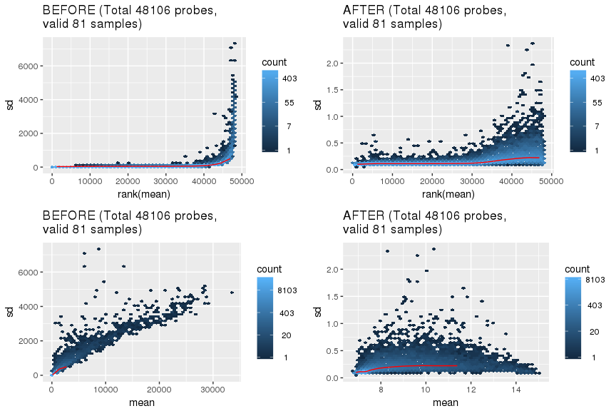

```r
# execute the filter step described above with this function
prepro_ht12 <- filterTechnicallyFailed(prepro_ht12, paramfile = myparamfile)
```

```
## Using:
## hybrid_low
## hybrid_med
## string_pm
## string_mm
## biotin
## negative
## as technical attributes for the technical score...
```

```
## Info: - control-category "biotin" 2 includes following probes: ILMN_1343049, ILMN_1343048
```

```
## Info: - control-category "housekeeping" 7 includes following probes: ILMN_2038774, ILMN_2038773, ILMN_2038777, ILMN_2038772, ILMN_1343295, ILMN_2038775, ILMN_2038776
```

```
## Info: - control-category "labeling" 2 includes following probes: ILMN_2038781, ILMN_1343059
```

```
## Info: - control-category "ercc" 92 includes following probes: ILMN_3164734, ILMN_3164750, ILMN_3164765, ILMN_3164808, ILMN_3164838, ILMN_3164858, ILMN_3164875, ILMN_3164905, ILMN_3164915, ILMN_3164950, ILMN_3164979, ILMN_3165007, ILMN_3165027, ILMN_3165033, ILMN_3165086, ILMN_3165100, ILMN_316511…
```

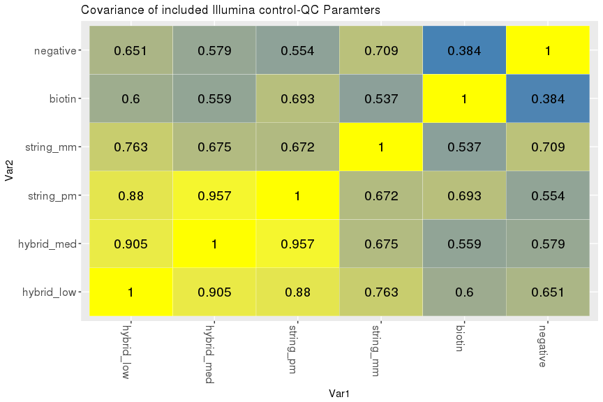

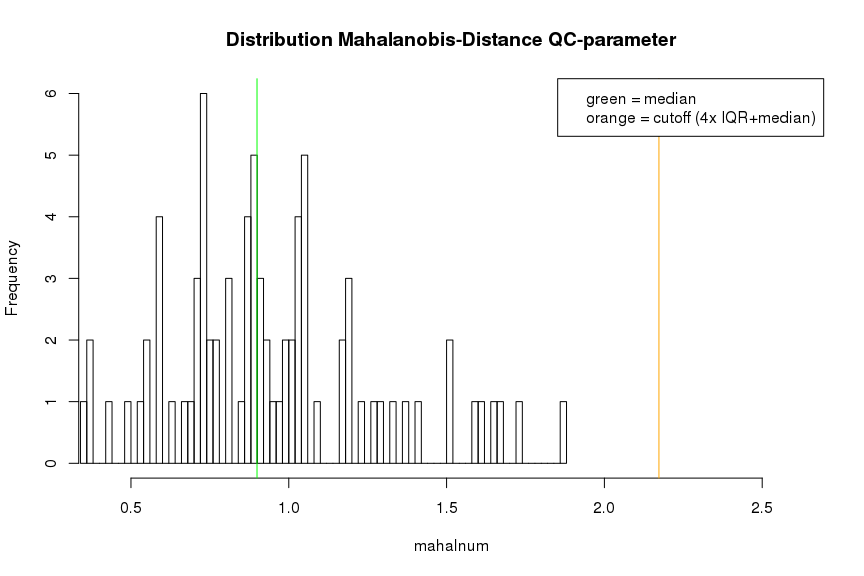

```
## In total, 0 samples were removed due to atypical combination of control probe levels, 81 samples are still valid...
```

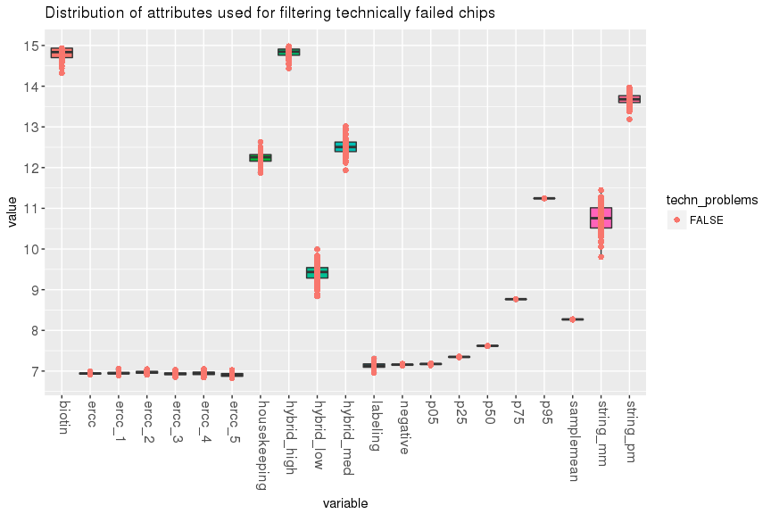

```r
# show command execution history
kable(prepro_ht12$history)
```

# Step 6 - Functions `filter4MinBatchsize()`, `transformNormalizeHT12object()`, and `removeBatchEffects()`: Transform and normalize still valid samples and adjust for batch-effects

- All expression probes (incl. control probes) of all still valid samples are log2-transformed and normalized (method quantile), again, as this procedure depends on the set of included samples
- Within the updated HT12prepro-object among others:
- The slot with sample-related attributes of the current processing-stage named `$chipsamples` is updated
- A slot with an expression set with normalized and transformed and batch-corrected data including control probe information is created: `$total_nobkgd_eset_ql_combat`
- The slot with the history of the commands named `$history`` is updated
- Several QC plots are shown, also see function `ComBat()` from the [R-package sva](https://bioconductor.org/packages/release/bioc/html/sva.html) for details

```r
# filter for batch-size
prepro_ht12 <- filter4MinBatchsize(prepro_ht12, paramfile = myparamfile)
```

```
## Filtering for batch size > 1 for Sentrix IDs...
```

```
## Removed 0 samples where only a single sample was found in at least one batch. (Removed IDs: )
```

```r
# repeat transformation and normalization
# This is only necessary if samples were removed in previous step
prepro_ht12 <- transformNormalizeHT12object(prepro_ht12, paramfile = myparamfile)
```

```
## Transforming and Normalizing expression sets of 81 samples still good according to column 'in_study'....
```

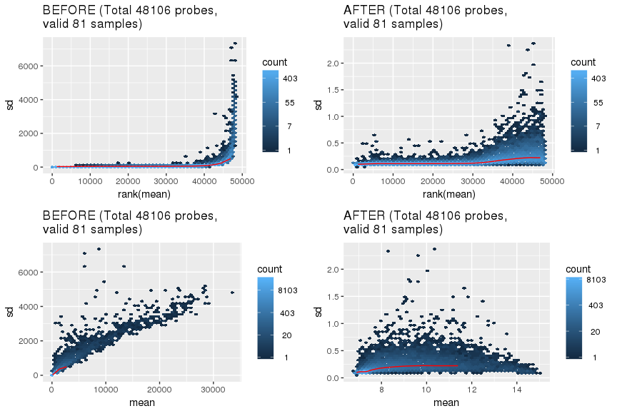

```r
# execute batch- adjustment via sva::ComBat()
prepro_ht12 <- removeBatchEffects(prepro_ht12, paramfile = myparamfile)
```

```
## NOT additionally protecting contrast `subgroup` in Combat...
```

```
## Found8batches
```

```
## Adjusting for0covariate(s) or covariate level(s)
```

```
## Fitting L/S model and finding priors
```

```
## Finding parametric adjustments
```

```
## Adjusting the Data
```

```
## Not doing a second adjustment round in combat
```

```
## Comparing expression set before and after  removing batch effects via ComBat...
```

```
## Found 48014 of 48014 probes of 1st eset in 2nd eset...
##
```

```
## Found 48014 of 48014 probes of 2nd eset in 1st eset...
##
```

```
## Working with intersect of 48014 probes
##
```

```
## Found 81 of 81 inds of 1st eset in 2nd eset...
##
```

```
## Found 81 of 81 inds of 2nd eset in 1st eset...
##
```

```
## Working with intersect of 81 samples...
##
```

```
## caclulated hist_groupfak probes=2400
```

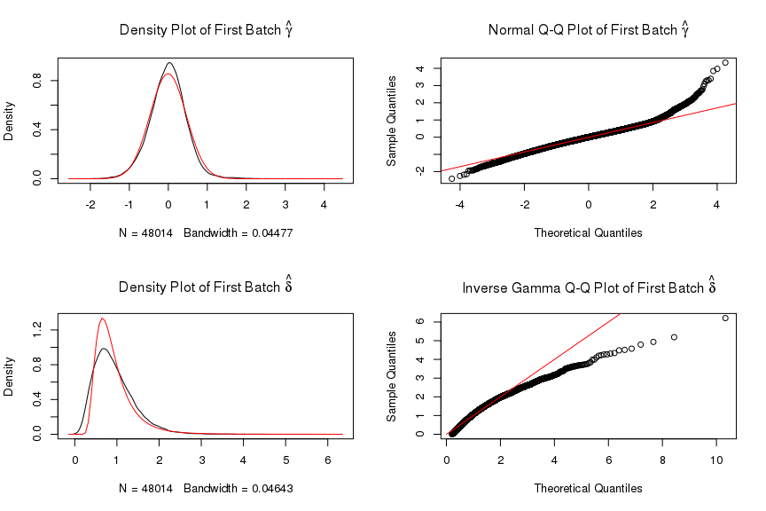

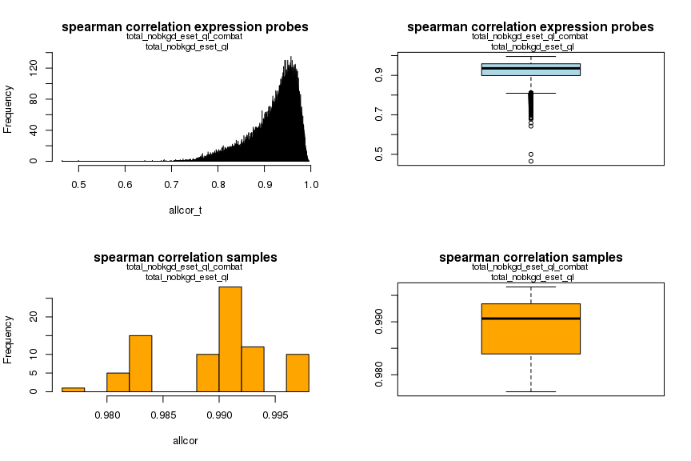

```r
# review command history
kable(prepro_ht12$history)
```

# Step 7 - Function `checkBatchEffects()`: Check for remaining batch effects

- Identification of transcripts where association with batches is still stronger than expected by chance after batch-adjustment. Stronger than chance (i.e. overinflation) is defined as association stronger p-value after Bonferroni correction
- All batches defined in step 2 will be tested, i.e. `Sentrix.Barcode`, `processingbatch`, and - if defined - `strangebatch`
- Probes are not filtered but annotated when found to be overinflated
- QQ plots of association are shown
- Within the updated HT12prepro-object among others,
- The slot with probe-related attributes of the current processing-stage named `$genesdetail` is updated
- The slot with the history of the commands named `$history` is updated

```r
# check for remaining batch-effects
prepro_ht12 <- checkBatchEffects(prepro_ht12, paramfile = myparamfile)
```

```
## Found 8 different sentrix IDs...
```

```
## Found 2 different processingbatches ...
```

```
## No different batches present assigned as specialbatches
```

```
## ... not adjusting ANOVA for subgroup ...
```

```
## Calculating ANOIVA for Sentrix.Barcode (n_sentrix > 2) before Combat...
```

```
## Processing covariates
```

```
## Task finished in 0.0029999999999859 seconds
```

```
## Processing gene expression data (imputation, residualization)
```

```
## Task finished in 0.250999999999976 seconds
```

```
## Creating output file(s)
```

```
## Task finished in 0.0190000000000055 seconds
```

```
## Performing eQTL analysis
```

```
## 10.00% done, 5,050 eQTLs
```

```
## 19.99% done, 10,100 eQTLs
```

```
## 30.00% done, 15,150 eQTLs
```

```
## 39.99% done, 20,200 eQTLs
```

```
## 50.00% done, 25,250 eQTLs
```

```
## 60.00% done, 30,300 eQTLs
```

```
## 70.00% done, 35,350 eQTLs
```

```
## 80.00% done, 40,400 eQTLs
```

```
## 89.99% done, 45,450 eQTLs
```

```
## 100.00% done, 48,106 eQTLs
```

```
## Task finished in 0.273000000000025 seconds
```

```
## For two examples, R ANOVA and MatrixEQTL in  ANOVA without Covariate are identical. Great.
```

```
## Calculating ANOIVA for Sentrix.Barcode (n_sentrix > 2) after Combat...
```

```
## Processing covariates
```

```
## Task finished in 0.00200000000000955 seconds
```

```
## Processing gene expression data (imputation, residualization)
```

```
## Task finished in 0.399000000000001 seconds
```

```
## Creating output file(s)
```

```
## Task finished in 0.00999999999999091 seconds
```

```
## Performing eQTL analysis
```

```
## 10.00% done, 5,050 eQTLs
```

```
## 19.99% done, 10,100 eQTLs
```

```
## 30.00% done, 15,150 eQTLs
```

```
## 39.99% done, 20,200 eQTLs
```

```
## 50.00% done, 25,250 eQTLs
```

```
## 60.00% done, 30,300 eQTLs
```

```
## 70.00% done, 35,350 eQTLs
```

```
## 80.00% done, 40,400 eQTLs
```

```
## 89.99% done, 45,450 eQTLs
```

```
## 100.00% done, 48,014 eQTLs
```

```
## Task finished in 0.226999999999975 seconds
```

```
## For two examples, R ANOVA and MatrixEQTL in  ANOVA without Covariate are identical. Great.
```

```
## Doing calcAnova() on total_nobkgd_eset_ql
```

```
## Doing calcAnova() on total_nobkgd_eset_ql_combat
```

```
## Define probes with not over-inflated ANOVA for subgroup PBMC...
```

```
## Created followin new sample attributes:
## all_pval_after_sentrix
## all_pval_after_bigbatch
## all_pval_after_strangebatch
## all_pval_before_sentrix
## all_pval_before_bigbatch
## all_pval_before_strangebatch
## all_pval_after_sentrix_bf
## all_pval_after_bigbatch_bf
## all_pval_after_strangebatch_bf
## all_pval_before_sentrix_bf
## all_pval_before_bigbatch_bf
## all_pval_before_strangebatch_bf
## goodexpressedprobe_PBMC
```

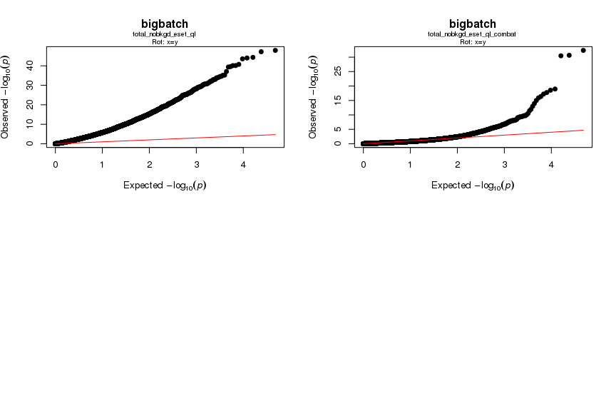

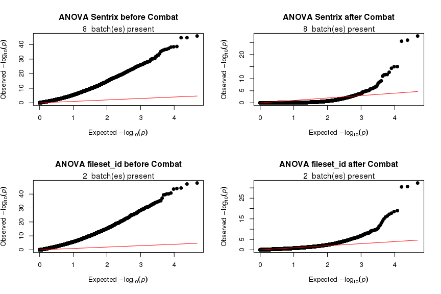

```r
# preview the newly created object
ht(prepro_ht12$genesdetail, 2)

# review command history
kable(prepro_ht12$history)
```

# Step 8 - Function `filterAtypicalExpressed()`: Identify samples with atypical expression values

- Filter samples for atypical gene expression levels
- This is defined as atypical large Euclidian distance of all expressed, not batch-associated expression probes
- Identified Outlyers are defined as having a greated distance than 3 interquantile ranges
- This number can be changed via parameter `filter2ind_atypischEuklid`
- **!Note** that sometimes it might be meaningful to repeat correction for batch association after excluding atypical samples identified in this step
- Within the updated HT12prepro-object among others,
- The slot with sample-related attributes of the current processing-stage named `$chipsamples` is updated
- The slot with the history of the commands named `$history` is updated

```r
# filter for atypical expression levels
prepro_ht12 <- filterAtypicalExpressed(prepro_ht12, paramfile = myparamfile)
```

```
## Starting calculation of Euclidian distance
```

```
## Finished calculation of Euclidian distance within 4.14 secs
```

```
## Removed 1 Individuals in Subgroup PBMC due to atypical Euclidian distance of gene expression data
```

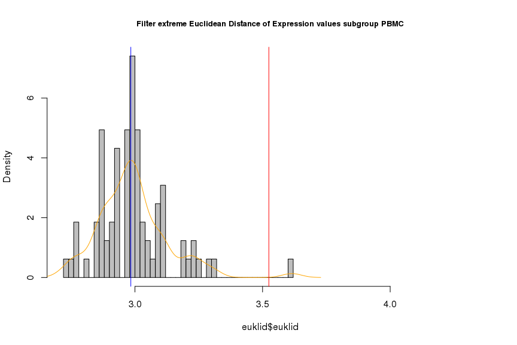

```r
# preview newly created output
ht(prepro_ht12$chipsamples, 2)

# review command history
kable(prepro_ht12$history)
```

# Step 9 - Function `visualizePreprocessing()` and `comparePCBeforeAfterPrePro()`: visualization of Quality Control measures

- Visualisation of control features before and after preprocessing in several plots
- Raw data before preprocessing is log2-transformed for a more meaningful comparison
- PCA on expression data is also done using good samples surviving preprocessing
- Following PCAs are calculated and shown as figures:
- PCA of all transcripts before preprocessing, including additional scaling
- PCA of gene expression after preprocessing using only expression probes that are expressed, not overinflated regarding batch affects and beeing specific to the human genome when considering a remapping approach according to Barbosa-Moralis et al. (2010)
- Within the updated HT12prepro-object among others,
- plots are also stored in slot `$dokuobjects_visualizePreprocessing`
- the slot with the history of the commands named `$history` is updated

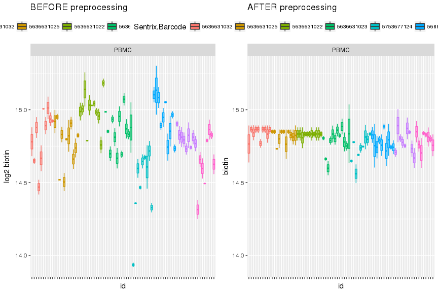

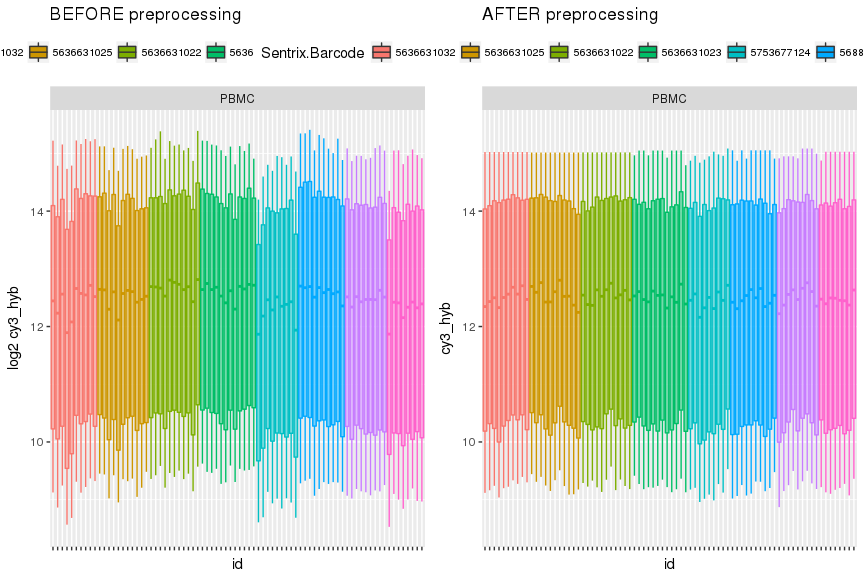

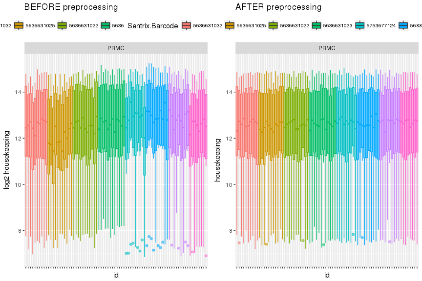

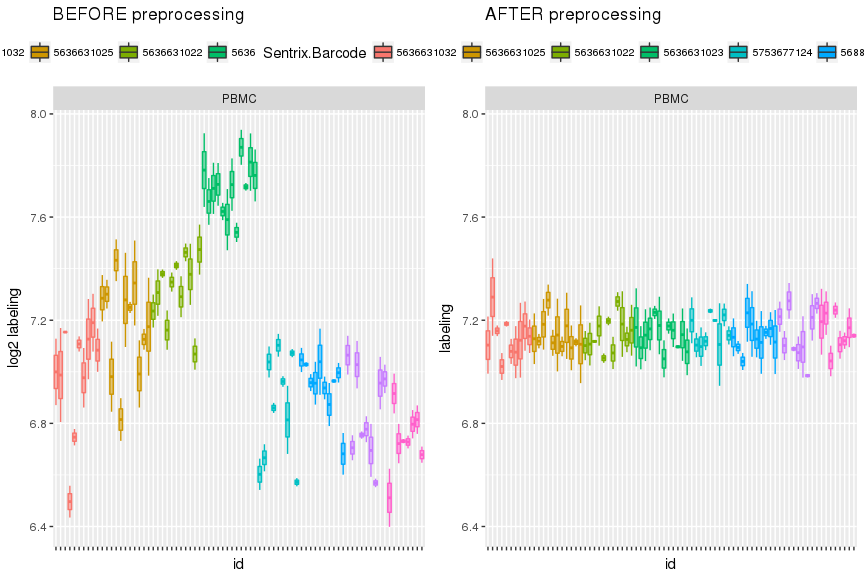

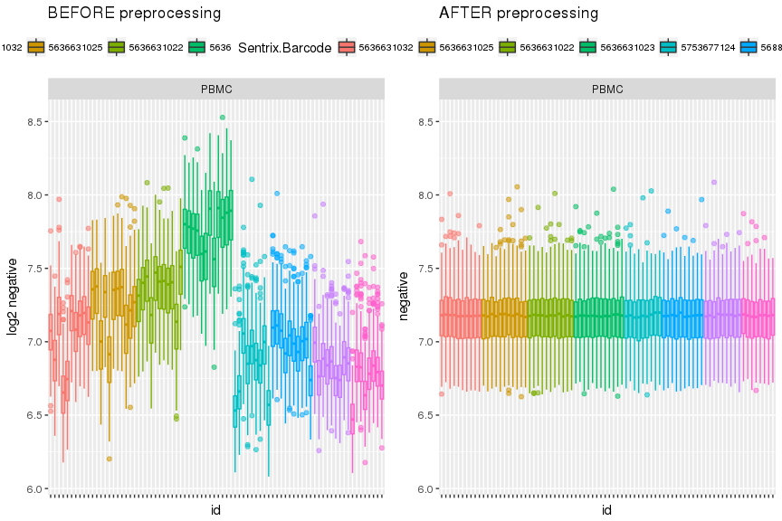

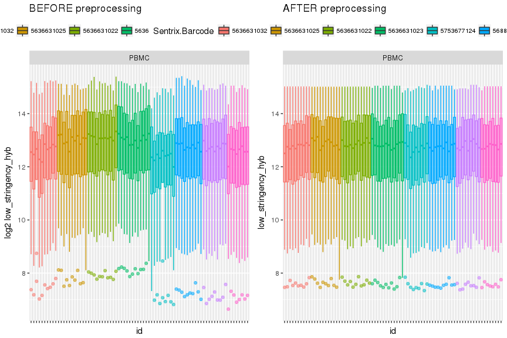

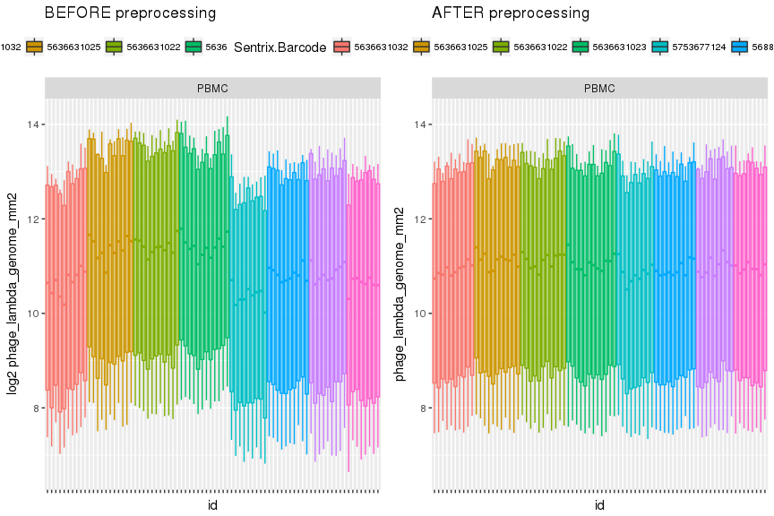

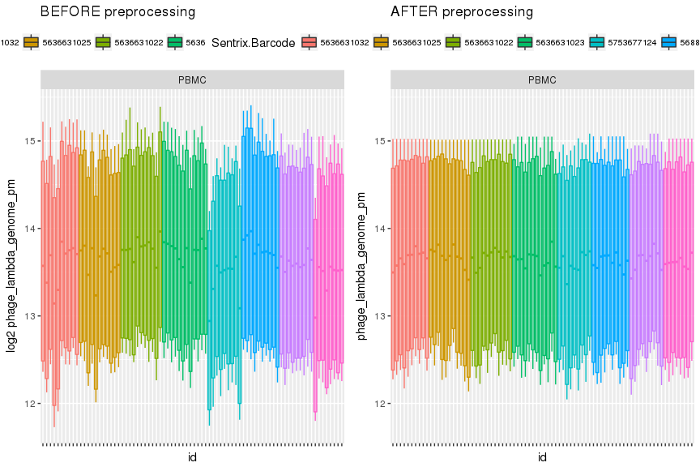

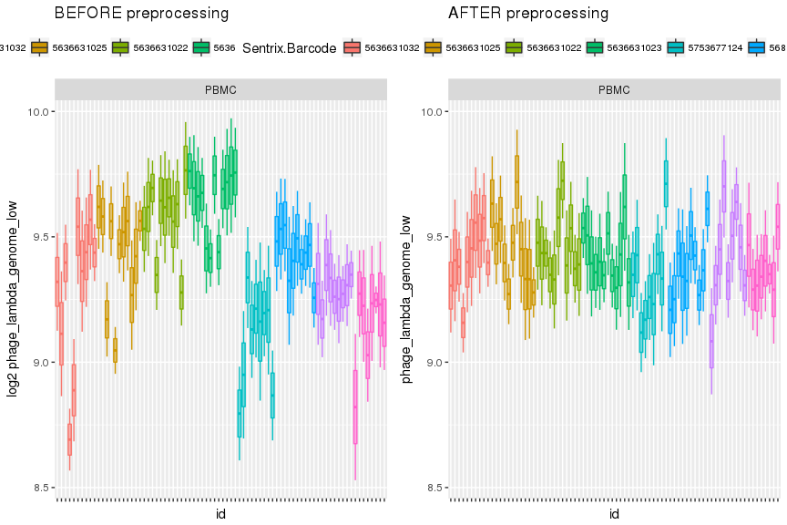

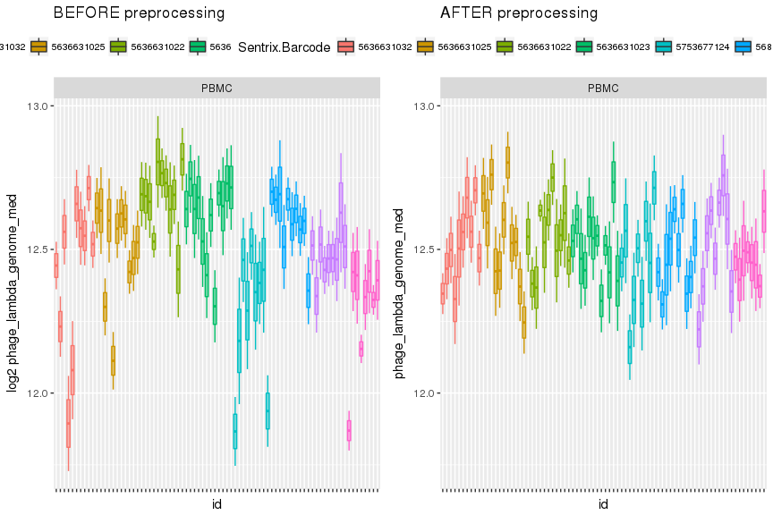

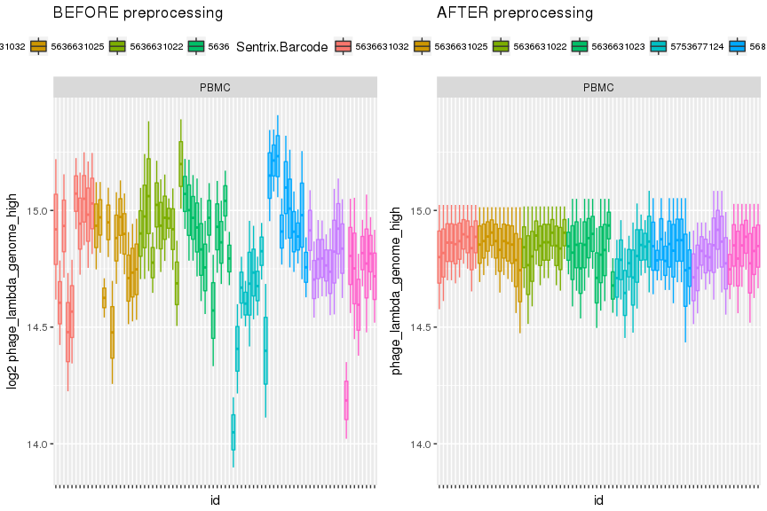

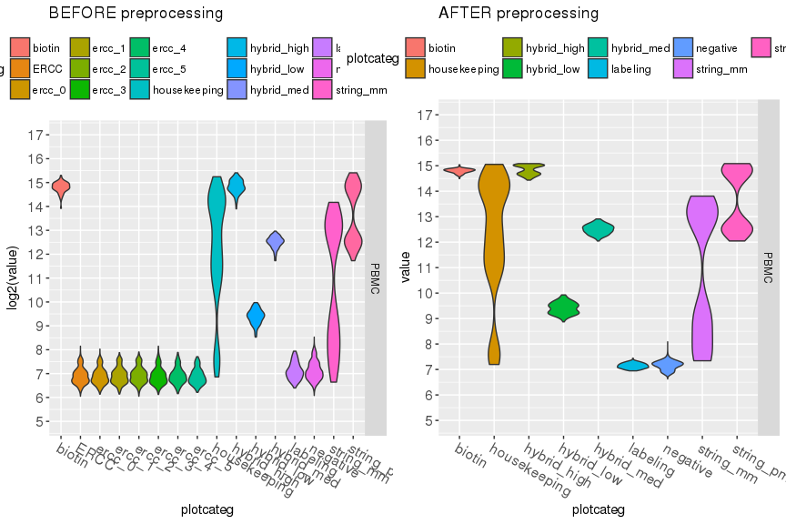

[1 more figures not shown]

```r
# create QC-plots
prepro_ht12 <- visualizePreprocessing(prepro_ht12, paramfile = myparamfile)
```

```r
# PCA before/after preprocessing
prepro_ht12 <- comparePCBeforeAfterPrePro(prepro_ht12, paramfile = myparamfile)
```

[figure not shown]

[figure not shown]

[figure not shown]

[figure not shown]

```r
# review command history
kable(prepro_ht12$history)
```

[output not shown]

# Step 10 - Function `writeFilesTosend()`: Write preprocessed data

The directory of the resulting preprocessed data was specified in step *Preparations*

- Individual filenames can be customized by specifying parameters:
- `file_sampleannot_final.txt`: default is sampleannot_HT12v4.txt –> annotation of samples
- `file_probeannot_final.txt`: default is probeannot_HT12v4.txt –> annotation of probes
- `file_annot_final.xlsx`: default is sampleUNDprobeannot_HT12v4.xlsx –> annotation of samples and probes as excel file
- `file_final_expression_set`: default is expressionset_preprocessed.Rdata –> Preprocessed data as expression set
- `file_final_expression_matrix`: default is expressionmatrix_preprocessed.Rdata –> Preprocessed data as R-Matrix
- `file_all_transcripts_good_incl_remapping_ok`: default is all_transcripts_good_incl_remapping_ok.txt –> IDs of probes that are considered expressed in all subgroups, have no remaining batch effect stronger than expected by chance, and are ok given a remapping approach of Barbosa-Moralis et al. (2010) – Note that probes with a remaining batch effect might still be included in association analysis if no nominal significant correllation is found between the batch and the analysis variable of interest
- `file_final_expression_matrix_allProbes.txt`: default is expressionmatrix_preprocessed.txt –> Filename of expression matrix as tab delimited text file after finished preprocessing

Parameter `file_renaming_samples_tosend` can specify a filename where a column named `oldname` and `newname` is provided in order to rename sample. Column `oldname` must match the names of the samples in column `new_ID` in the `$chipsamples` data.frame included in the HT12 object. Can be empty if no renaming is required

- **!Note** that expression values are not residualised for any covariates e.g. age, sex, or any other phenotypic variable or any principal component of expression data

```r
## Set parameter to use provided renaming file
renaming_fn <- system.file("extdata", "renamingsamples.txt", package = "HT12ProcessoR")

# edit parameter file with location of renaming-file
myparams[ myparams$variable == "file_renaming_samples_tosend", "value"] <- renaming_fn

# write the parameter file
write.table(myparams,
            myparamfile,
            quote = F,
            col.names = T,
            row.names = F,
            sep="\t")

# write result files into the tosend/ folder
prepro_ht12 = writeFilesTosend(prepro_ht12, paramfile = myparamfile)
```

```
## Writing annotation files as txt...
```

```
##
## ... directory /net/ifs1/san_projekte/projekte/Doktoranden/CarlBeuchel/6_RPackages/HT12ProcessoR/vignettes/tosend/ already exists...
##
## ... directory /net/ifs1/san_projekte/projekte/Doktoranden/CarlBeuchel/6_RPackages/HT12ProcessoR/vignettes/tosend/ already exists...
##
## ... directory /net/ifs1/san_projekte/projekte/Doktoranden/CarlBeuchel/6_RPackages/HT12ProcessoR/vignettes/tosend/ already exists...
```

```
## Writing expression data files..
```

```
##
## ... directory /net/ifs1/san_projekte/projekte/Doktoranden/CarlBeuchel/6_RPackages/HT12ProcessoR/vignettes/tosend/ already exists...
```

```
## Writing annotation files as xlsx...
```

```r
# preview first and last line of $chipsamples object
ht(prepro_ht12$chipsamples, 1)

# review command history
kable(prepro_ht12$history)
```

[output not shown]

It might be helpful, to save the HT12-object to preserve detailed information on preprocessing

```r
# save an .RData object containing the final prepro_ht12 object
save(prepro_ht12, file = paste0(prepro.folder, "/obj/prepro_example1_HT12object.RData"))
```

# Step 11 - Function `createTextForMethods()`: Information for Material and Methods section of a manuscript

This function creates an extended and a short version of the preprocessing done for section Material and Methods of a publication.

**Please slightly rephrase text as most journals require unique phrasing even in materials & methods section**

```r
# create text-object
mm_text <- createTextForMethods(prepro_ht12, paramfile = myparamfile)

# preview created text as a long version
cat('### Extended Version')
```